# Confidence Intervals

Kateřina Večerková vecerkok@vscht.cz

2025-01-22

# Confidence Intervals

## 1. **Introduction to Confidence Intervals**

- **What is a Confidence Interval (CI)?**
  - A confidence interval gives a range of values that is likely to contain a population parameter (like the mean) with a certain level of confidence (e.g., 95%).
  - Instead of giving a single estimate (point estimate), the CI provides an interval estimate.
- **Why are Confidence Intervals Useful?**
  - They account for sampling variability.
  - Provide more information than a point estimate by showing the precision of the estimate.
  - The wider the interval, the less precise the estimate but also the more confident; the narrower the interval, the more precise but less confident.

## 2. **Confidence Intervals for the Mean**

- **Case 1: Large Samples (n > 30, Z-statistic)**
  - When the sample size is large (n > 30), the **Z-statistic** is used to calculate the CI for the mean.
  - **Formula**:
    $$CI = \bar{x} \pm Z_{\alpha/2} \times \left(\frac{s}{\sqrt{n}}\right)$$
    - $\bar{x}$ = sample mean (průměr výběru)
    - $Z_{\alpha/2}$ = Z-critical value for the desired confidence level (e.g., 1.96 for 95% CI) (kritická hodnota Z pro požadovanou úroveň spolehlivosti)
    - $s$ = sample standard deviation (směrodatná odchylka výběru)
    - $n$ = sample size (velikost výběru)
  - **Example in R:**

```r
# Confidence Interval for n > 30
x <- rnorm(100, mean = 100, sd = 15)
n <- length(x)
x_bar <- mean(x)
z <- qnorm(0.975)  # for 95% confidence level
se <- sd(x) / sqrt(n)
lower <- x_bar - z * se
upper <- x_bar + z * se
c(lower, upper)
```

```
## [1]  94.50511 100.53288
```

- **Case 2: Small Samples (n < 30, t-statistic)**
  - For small sample sizes (n < 30), we use the **t-statistic** instead of the Z-statistic.
  - **Formula**:
    $$CI = \bar{x} \pm t_{\alpha/2, df} \times \left(\frac{s}{\sqrt{n}}\right)$$
  - $t_{\alpha/2, df}$ = t-critical value (depends on confidence level and degrees of freedom, df = n - 1) (kritická hodnota t závislá na stupních volnosti)
  - All other terms are the same as for large samples.
- **Example in R:**

```r
# Confidence Interval for n < 30
x <- rnorm(20, mean = 100, sd = 15)
n <- length(x)
x_bar <- mean(x)
t_stat <- qt(0.975, df = n - 1)
se <- sd(x) / sqrt(n)
lower <- x_bar - t_stat * se
upper <- x_bar + t_stat * se
c(lower, upper)
```

```
## [1]  91.8126 105.4433
```

## 3. **Interpreting Confidence Intervals**

- **How to Interpret a Confidence Interval**:
  - A 95% confidence interval means: “We are 95% confident that the true population mean lies within this interval.”
  - **Czech Translation**: „S 95% jistotou můžeme říci, že skutečný populační průměr leží v tomto intervalu.“
  - Example: If the CI for the mean height of a population is [165, 175], it means we are 95% confident that the true average height is between 165 and 175 cm.
- **Key Considerations**:
  - **Wider intervals** indicate more uncertainty (širší intervaly značí větší nejistotu).
  - **Narrower intervals** indicate more precision (užší intervaly značí větší přesnost).

## 4. **Visualizing Confidence Intervals**

- **Plotting CIs using R**:
  - It’s often useful to visualize CIs to understand the uncertainty around point estimates.
  - Example: Bootstrapped confidence intervals for sample means.

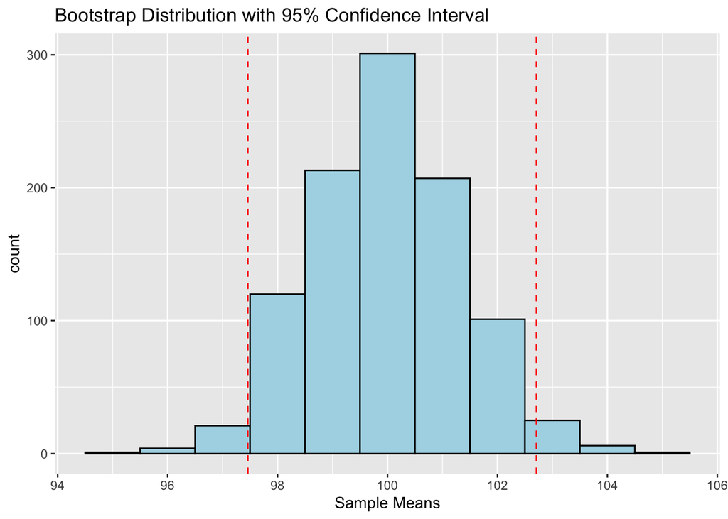

```r
library(ggplot2, quiet=TRUE)
# Sample data and CI calculation
x <- rnorm(100, mean = 100, sd = 15)
boot_means <- replicate(1000, mean(sample(x, size = 100, replace = TRUE)))
ci <- quantile(boot_means, c(0.025, 0.975))

# Visualizing CI
ggplot(data.frame(x = boot_means), aes(x = x)) +
 geom_histogram(binwidth = 1, fill = "lightblue", color = "black") +
 geom_vline(xintercept = ci, color = "red", linetype = "dashed") +
 labs(title = "Bootstrap Distribution with 95% Confidence Interval", x = "Sample Means")
```

## 5. **Term Vocabulary (Slovník pojmů)**

| **English Term** | **Czech Translation** | **Explanation** |
| --- | --- | --- |
| Confidence Interval (CI) | Interval spolehlivosti | A range of values that is likely to contain the true population parameter (mean, proportion). |
| Confidence Level | Úroveň spolehlivosti | The percentage that indicates how often the true parameter will lie within the interval (e.g., 95%). |
| Significance Level ($\alpha$) | Hladina významnosti ($\alpha$) | The probability of rejecting the null hypothesis when it is true. For confidence intervals, $\alpha$ is $1 - \text{confidence level}$. |
| Sample Mean ($\bar{x}$) | Průměr výběru | The average of sample data, used as a point estimate for the population mean. |
| Standard Error (SE) | Standardní chyba | The standard deviation of the sampling distribution of the sample mean. |
| Z-statistic | Z-statistika | The statistic used for large sample sizes (n > 30) to calculate the confidence interval. |
| t-statistic | t-statistika | The statistic used for small sample sizes (n < 30) to calculate the confidence interval. |
| Sample Size (n) | Velikost výběru | The number of observations in the sample. |
| Population Parameter | Populační parametr | The value (like the mean) that we are trying to estimate from the sample. |
| Margin of Error | Chyba odhadu | The amount added and subtracted from the point estimate to create the confidence interval. |
| Degrees of Freedom (df) | Stupně volnosti | In a t-distribution, df = n - 1, where n is the sample size. |
| Critical Value | Kritická hodnota | The value from the Z or t-distribution that defines the margin of error for the interval. |

# Conclusion

- Confidence intervals give us a range where the true population parameter is likely to be found.
- For large samples, we use the Z-statistic, and for small samples, we use the t-statistic.
- The width of the interval depends on the sample size, confidence level, and variability of the data.